# Análisis series temporales: Colgate VS Crest

Adrián González Retamosa

23/18/2020

# OBJETIVOS

El objetivo del presente trabajo es realizar un análisis de la evolución de las cuotas de mercado de las empresas Colgate y Crest desde 1958 hasta principios de 1963. Para ello se utilizaran modelos ARIMA, ARIMAX, con análisis de intervención y busqueda de outliers, y funciones de tranferencia con la idea de generar un modelo que ayude a predecir las 16 primeres semanas de 1963. Este estudio se realiza en el marco de la competencia y la utilidad del marketing, ya que como es sabido, Colgate disfrutaba de una cuota de mercado cercana al 40% hasta el 1 de agosto de 1960, cuando la asociación de dentistas de EEUU realizaron un comunicado recomendando el uso de Crest. A partir de dicha fecha la cuota de Crest superó a la de Colgate.

# Esquema

1. Presentación de las series temporales
2. Modelos ARIMA
3. Modelos ARIMAX, análisis de intervención y outliers.
4. Funcion de transferencia.

## 1. Presentación de las series temporales

```r
library(readxl)
library(forecast)
library(xts)
library(ggplot2)
library(reshape)
library(ggfortify)
library(tidyverse)
library(TSA)
library(Hmisc)
library(stats)
```

Como se observa en el gráfico, a partir del verano de 1960 la cuota de mercado de Crest superó a la de Colgate debido al anuncio de la ADA. Desde un punto de vista de análisis de series temporales comprobamos que las series no son estacionarias en media ya que presentan claras tendencias.

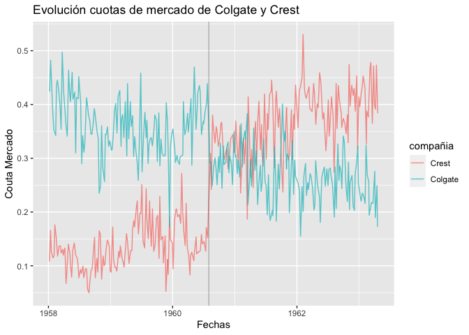

Para trabajar con este dataset converitrimeos las variables en series temporales y objetos zoo.

Con el gráfico de BoxCox se comprueba que no son necesarias transformaciones logarítmicas, ya que no se reducirá de forma significativa la varinza de las series.

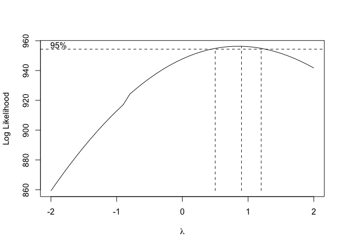

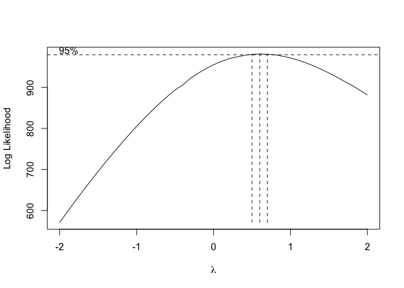

## 2. Modelos ARIMA

### 2.1. Colgate

El modelo ARIMA que se obtiene para la serie de Colgate es una media móvil de orden 1 en la parte regular y un autoregresivo de orden 1 en la parte estacional. Además, ha sido necesaria una diferencia regular para convertir la serie a estacionaria

Con el correlograma de los residuos y el contraste de Ljung se observa que estos siguen un ruido blanco, por lo que podemos decir que el modelo estimado es válido estadisticamente.

```
## Series: train_colgate
## ARIMA(0,1,1)(1,0,0)[52]
##
## Coefficients:
##           ma1    sar1
##       -0.7571  0.0232
## s.e.   0.0470  0.0682
##
## sigma^2 estimated as 0.00232:  log likelihood=418.63
## AIC=-831.25   AICc=-831.16   BIC=-820.58
##
## Training set error measures:
##                        ME       RMSE        MAE       MPE     MAPE      MASE
## Training set -0.002534821 0.04788855 0.03773876 -3.019377 12.77398 0.6038201
##                    ACF1
## Training set 0.05216089
```

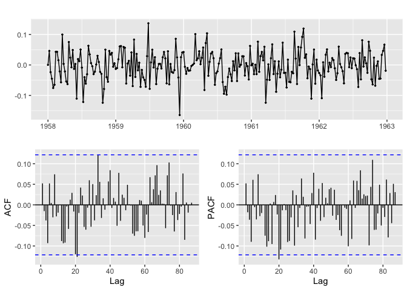

```
##
##  Box-Ljung test
##
## data:  mcolgate_arima$residuals
## X-squared = 23.836, df = 22, p-value = 0.3559
```

Antes de realizar el aálisis de intervencion buscamos posibles outliers en la serie temporal de Colgate pero no detectamos ninguno, ni en el modelo arima especificado ni el los residuos de dicho modelo.

```
## [1] "No AO detected"
```

```
## [1] "No IO detected"
```

### 2.2. Crest

El modelo ARIMA que se estima para la serie de Crest es una media móvil de orden 1 en la parte regular y sin estructura en la parte estacional. Se ha tomado también una diferencia regular para convertir la serie a estacionaria. Con el correlgrama de los residuos y el contraste de Ljung se comprueba que el modelo es válido estadisticamente.

```
## Series: train_crest
## ARIMA(0,1,1)
##
## Coefficients:
##           ma1
##       -0.6494
## s.e.   0.0448
##
## sigma^2 estimated as 0.002054:  log likelihood=434.08
## AIC=-864.15   AICc=-864.1   BIC=-857.04
##
## Training set error measures:
##                       ME       RMSE        MAE       MPE     MAPE      MASE
## Training set 0.003018071 0.04514444 0.03445351 -2.924537 17.27068 0.3800355
##                     ACF1
## Training set -0.04605961
```

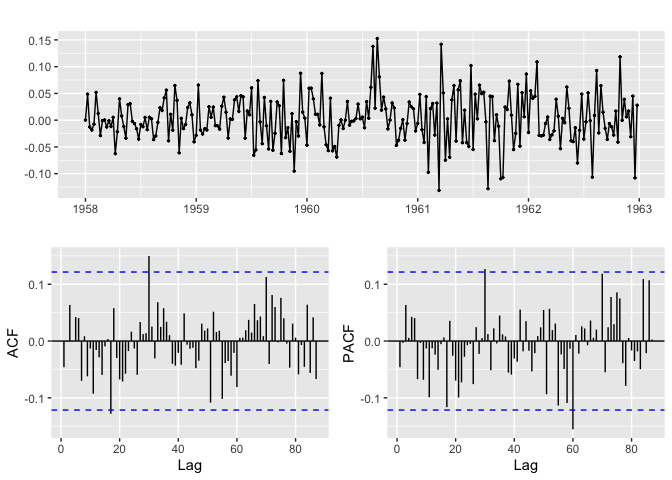

```
##
##  Box-Ljung test
##
## data:  mcrest_arima$residuals
## X-squared = 18.293, df = 22, p-value = 0.6885
```

```
##               [,1]       [,2]       [,3]
## ind     135.000000 136.000000 138.000000
## lambda2   3.918954   4.372891   4.005427
```

```
## [1] "No IO detected"
```

## 3. Modelos ARIMAX, análisis de intervención y outliers.

### 3.1. Colgate

Con el modelo ARIMAX realizamos el anális de intervención. En el caso de Colgate hemos colocado una variable impulso en la semana número 50 de 1959 y una variable escalón en la semana numero 30 de 1960, que corresponde con el anuncio de la ADA a favor del uso de productos de la marca Crest. No hemos introducido ningun otro outliers ya que no creeemos que sea necesario.

En el grafico se muestra como nuestro modelo capta, casi a la perfección, las dos distorsiones que sufre la serie, lo que genera un modelo mas completo a la hora de predicciones futuras.

```
##
## Call:
## arimax(x = train_colgate, order = c(0, 1, 1), seasonal = list(order = c(1, 0,
##     0), period = 52), method = "ML", xtransf = data.frame(I5059 = 1 * (seq(train_colgate) ==
##     102), E3060 = 1 * (seq(train_crest) >= 134)), transfer = list(c(1, 0), c(1,
##     0)))
##
## Coefficients:
##           ma1    sar1  I5059-AR1  I5059-MA0  E3060-AR1  E3060-MA0
##       -0.7982  0.0251     0.0431    -0.1597     0.6708    -0.0383
## s.e.   0.0462  0.0710     0.2487     0.0437     0.1436     0.0168
##
## sigma^2 estimated as 0.002106:  log likelihood = 430.07,  aic = -848.13
```

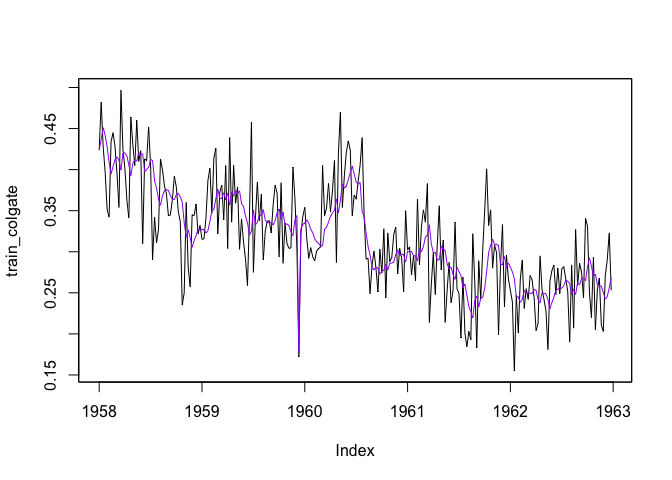

```
##         ma1        sar1   I5059-AR1   I5059-MA0   E3060-AR1   E3060-MA0
## -0.79823298  0.02509751  0.04313631 -0.15965018  0.67082704 -0.03825897
```

Despues de la intervención buscamos outliers en el modelo y en sus residuos y observamos que no los hay.

```
## [1] "No AO detected"
```

```
## [1] "No IO detected"
```

### 3.2. Crest

En primer lugar, generaremos un modelo ARIMAX para la serie Crest sin tener en cuenta los outliers detectados, para asi realizar una comparación entre ambos modelos.

El anális de intervención realizado consta de un escalón abrupto en el mes de agosto de 1960, por las mismas razones que en la serie de Colgate.

```
##
## Call:
## arimax(x = train_crest, order = c(0, 1, 1), method = "ML", xtransf = data.frame(E3460 = 1 *
##     (seq(train_crest) >= 138), E3460 = 1 * (seq(train_crest) == 137)), transfer = list(c(0,
##     0), c(1, 0)))
##
## Coefficients:
##           ma1  E3460-MA0  E3460.1-AR1  E3460.1-MA0
##       -0.7436     0.1283       0.8193       0.0499
## s.e.   0.0478     0.0390       0.2829       0.0373
##
## sigma^2 estimated as 0.001898:  log likelihood = 443.67,  aic = -879.35
```

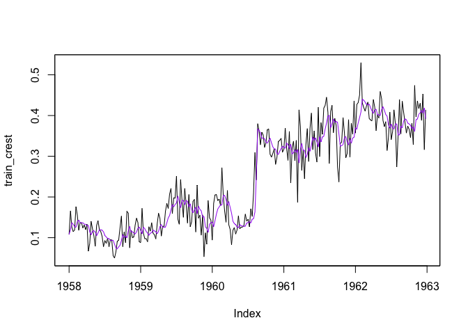

A continuación generamos otro modelo ARIMAX para la serie Crest introducciendo los outliers detectado con posterioridad, y comprobamos que mejoramos el valor del criterio AIC ya que nuestro nuevo modelo se adapta mejor a los datos atípicos.

```
##
## Call:
## arimax(x = train_crest, order = c(0, 1, 1), xreg = data.frame(o3160 = 1 * (seq(train_crest) ==
##     135), o3260 = 1 * (seq(train_crest) == 136), o0562 = 1 * (seq(train_crest) ==
##     213)), method = "ML", xtransf = data.frame(E3460 = 1 * (seq(train_crest) >=
##     138), E3460 = 1 * (seq(train_crest) == 137)), transfer = list(c(0, 0), c(1,
##     0)))
##
## Coefficients:
##           ma1   o3160   o3260   o0562  E3460-MA0  E3460.1-AR1  E3460.1-MA0
##       -0.7716  0.0632  0.1608  0.1193     0.1597       0.8105       0.0871
## s.e.   0.0450  0.0414  0.0423  0.0395     0.0486       0.2775       0.0354
##
## sigma^2 estimated as 0.001736:  log likelihood = 455.13,  aic = -896.26
```

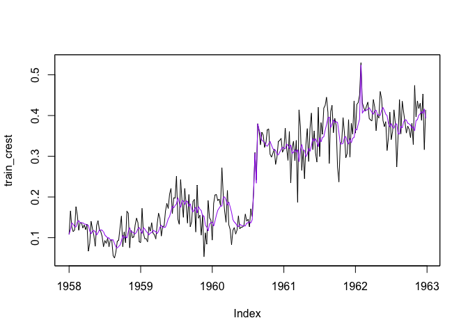

Para terminar este apartado buscaremos si sigue habiendo ouliers en nuestro modelo o en sus residuos despues de esta segunda intervención, y comprobamos que no.

```
## [1] "No AO detected"
```

```
## [1] "No IO detected"
```

## 4. Funcion de transferencia.

r = 0

s = 0

```
##
## Call:
## arimax(x = train_colgate, order = c(0, 1, 1), seasonal = list(order = c(1, 0,
##     0), period = 52), include.mean = TRUE, method = "ML", xtransf = train_crest,
##     transfer = list(c(0, 15)))
##
## Coefficients:
##           ma1    sar1  xtransf-MA0  xtransf-MA1  xtransf-MA2  xtransf-MA3
##       -0.8315  0.0417      -0.5016      -0.0351      -0.0364      -0.0248
## s.e.   0.0398  0.0816       0.0577       0.0582       0.0591       0.0597
##       xtransf-MA4  xtransf-MA5  xtransf-MA6  xtransf-MA7  xtransf-MA8
##            0.0909      -0.0291       0.0754       0.0198      -0.0141
## s.e.       0.0600       0.0598       0.0603       0.0602       0.0602
##       xtransf-MA9  xtransf-MA10  xtransf-MA11  xtransf-MA12  xtransf-MA13
##           -0.0157       -0.0473        0.0326        0.0098        0.0774
## s.e.       0.0612        0.0610        0.0610        0.0628        0.0605
##       xtransf-MA14  xtransf-MA15
##             0.0181       -0.0446
## s.e.        0.0598        0.0591
##
## sigma^2 estimated as 0.001659:  log likelihood = 434.16,  aic = -832.32
##
## Training set error measures:
##                         ME       RMSE        MAE       MPE     MAPE      MASE
## Training set -1.596551e-06 0.04064289 0.03121532 -1.681264 10.56647 0.6688812
##                   ACF1
## Training set 0.0804764
```

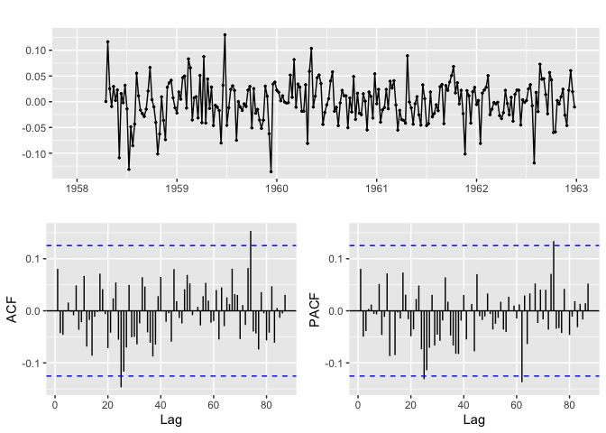

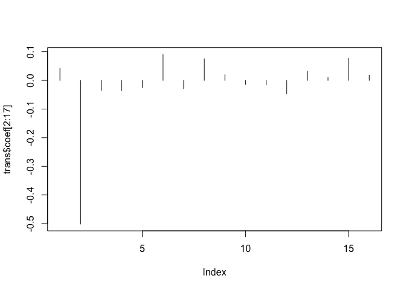

Volvemos a definir la funcion de transferencia a partir de los valores elegidos

```
##
## Call:
## arimax(x = train_colgate, order = c(0, 1, 1), seasonal = list(order = c(1, 0,
##     0), period = 52), include.mean = TRUE, fixed = c(NA, NA, 0, NA), method = "ML",
##     xtransf = train_crest, transfer = list(c(0, 1)))
##
## Coefficients:
##           ma1    sar1  xtransf-MA0  xtransf-MA1
##       -0.7926  0.0228            0      -0.0884
## s.e.   0.0534  0.0684            0       0.0776
##
## sigma^2 estimated as 0.002298:  log likelihood = 417.15,  aic = -828.3
##
## Training set error measures:
##                        ME       RMSE        MAE       MPE     MAPE      MASE
## Training set -0.002806092 0.04784903 0.03772933 -3.096149 12.78665 0.8084634
##                    ACF1
## Training set 0.04245359
```

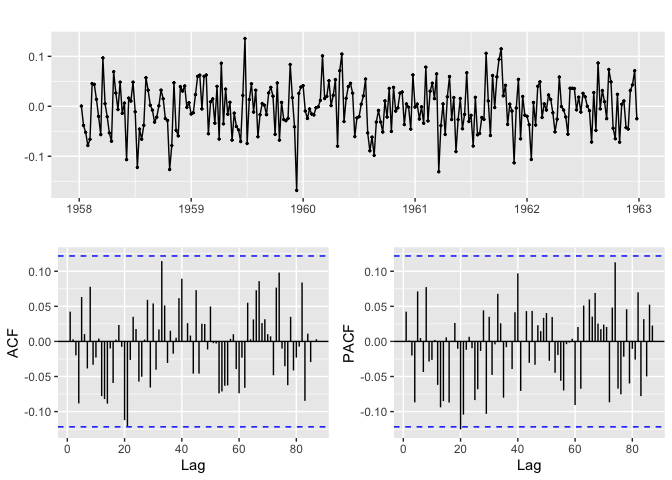

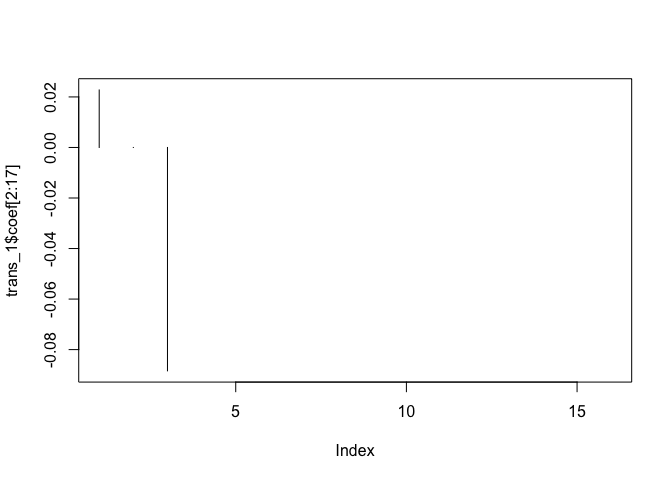